# Презентация по второй лабораторной работе

Атрибуты файлов

Дауд Амжад

1032245416@rudn.ru

Российский университет дружбы народов

2026-2-21

# Информация

## Докладчик

Дауд Амжад

студентка

Российский университет дружбы народов им. П. Лумумбы

1032245416@rudn.ru

https://amjaddawud.github.io/ru/

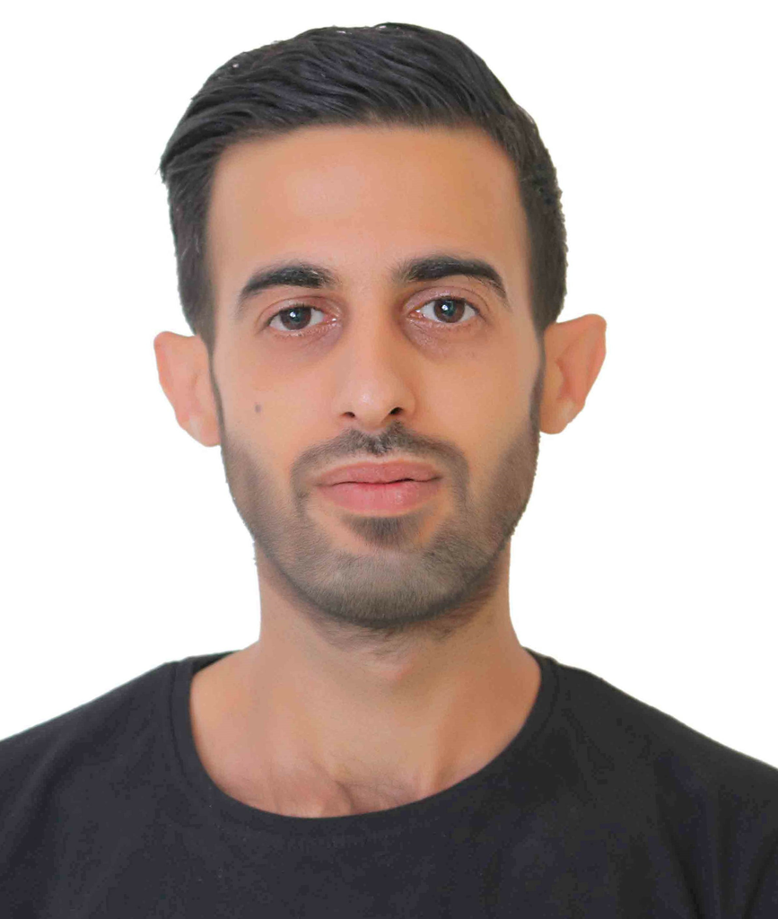

# Вводная часть

## Цель работы

Получение навыков работы в консоли с атрибутами файлов, закрепление теоретических основ дискреционного разграничения доступав современных системах с открытым кодом на базе ОС Linux.

## Задание

1. Работа с атрибутами файлов
2. Заполнение таблиц

# Выполнение лабораторной работы

## Атрибуты файлов

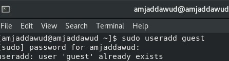

создание пользователя

## Атрибуты файлов

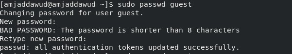

Добавление пароля для guest

## Атрибуты файлов

Вхожу в системе от имени ползователя guest и определяю, где нахожусь с помощью pwd.

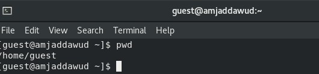

текущая директория

## Атрибуты файлов

Уточняю имя пользователя.

## Атрибуты файлов

Groups выводит информция о названии группы, к которой относится пользователь. id выводит больше информации чем groups (имя пользователя и группыб коды группы и пользователя).

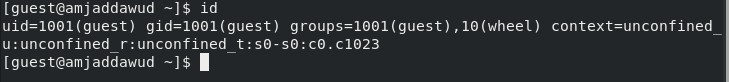

Информация о пользователе

## Атрибуты файлов

С помощью cat /etc/passwd | grep guest вывожу свою учетную запись и адрес домашней директории.

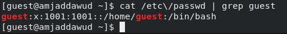

Посмотра файла passwd

[figure not shown]

## Атрибуты файлов

список поддиректорий директории home получилось получить с помощью команды ls -l

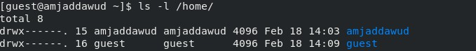

Список поддиректорий

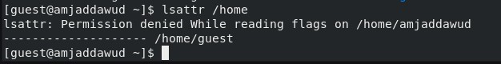

[figure not shown]

Список поддиректорий

## Атрибуты файлов

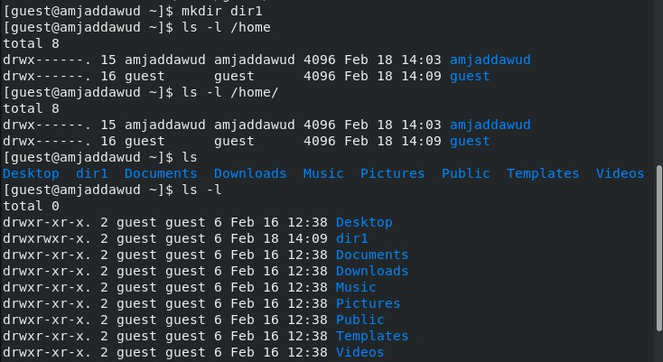

Создание поддиректории

## Атрибуты файлов

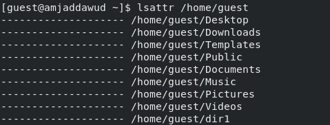

Проверка расширенных атрибутов

## Атрибуты файлов

Снимаю атрибуты командой chmod 000 dir1, при проверке с помощью команды ls -l видно, что теперь атрибуты действительно сняты.

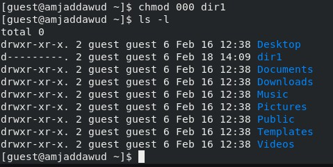

Снятие атрибутов с директории

## Атрибуты файлов

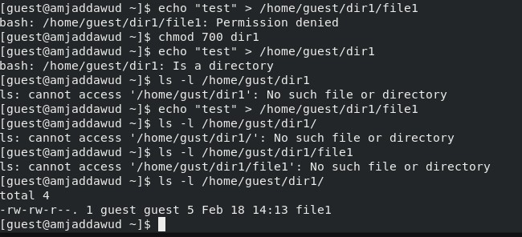

Попытка создания файла

# Выводы

При выполнении проделанной работы я получила практические навыки работы в консоли с атрибутами файлов, закрепление теоретических основ дискреционного разграничения доступав современных системах с открытым кодом на базе ОС Linux.